# Causal ML: Group Average Treatment Effects

Simulation notebook

Michael Knaus

01/24

Goals:

- Handcode DR-learner for GATE estimation with OLS, Kernel and Series regression

# Linear heterogeneity

## DGP

Consider the following DGP with linear heterogeneous treatment effects:

- $p=10$ independent covariates $X_1,...,X_k,...,X_{10}$ drawn from a uniform distribution: $X_k \sim uniform(-\pi,\pi)$
- The treatment model is $W \sim Bernoulli(\underbrace{\Phi(sin(X_1))}_{e(X)})$, where $\Phi(\cdot)$ is the standard normal cumulative density function
- The potential outcome model of the controls is $Y(0) = \underbrace{sin(X_1)}_{m_0(X)} + \varepsilon$, with $\varepsilon \sim N(0,1)$
- The CATE function is a linear function of the first three covariates $\tau(X) = \underbrace{0.3}_{\rho_1} X_1 + \underbrace{0.2}_{\rho_2} X_2 + \underbrace{0.1}_{\rho_3} X_3$
- The potential outcome model of the treated is $Y(1) = m_0(X) + \tau(X) + \varepsilon$, with $\varepsilon \sim N(0,1)$

This leads to substantial effect heterogeneity driven by the first three covariates:

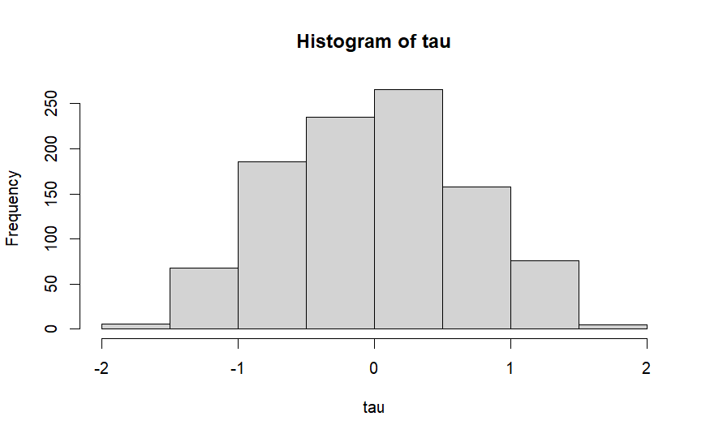

```r
if (!require("grf")) install.packages("grf", dependencies = TRUE); library(grf)
if (!require("tidyverse")) install.packages("tidyverse", dependencies = TRUE); library(tidyverse)
if (!require("patchwork")) install.packages("patchwork", dependencies = TRUE); library(patchwork)
if (!require("estimatr")) install.packages("estimatr", dependencies = TRUE); library(estimatr)
if (!require("np")) install.packages("np", dependencies = TRUE); library(np)
if (!require("crs")) install.packages("crs", dependencies = TRUE); library(crs)
if (!require("causalDML")) {
  if (!require("devtools")) install.packages("devtools", dependencies = TRUE); library(devtools)
  install_github(repo="MCKnaus/causalDML")
}; library(causalDML)

set.seed(1234)

# Set parameters
n = 1000
p = 10

rho = c(0.3,0.2,0.1,rep(0,7))

# Draw sample
x = matrix(runif(n*p,-pi,pi),ncol=p)
e = function(x){pnorm(sin(x))}
m0 = function(x){sin(x)}
tau = x %*% rho
w = rbinom(n,1,e(x[,1]))
y = m0(x[,1]) + w*tau + rnorm(n,0,1)
hist(tau)
```

## GATE estimation with OLS

### Hand-coded 2-fold cross-fitting

Consider that we are interested in the heterogeneity with respect to the first five covariates, $X_1$ to $X_5$.

We draw a sample of $N=1000$ and estimate the nuisance parameters $e(X)=E[W|X]$, $m(0,X)=E[Y|W=0,X]$ and $m(1,X)=E[Y|W=1,X]$ using honest random forest with self-tuned tuning parameters and all ten covariates.

We first handcode 2-fold cross-validation and plug the resulting nuisance parameters into the pseudo outcome
$$\tilde{Y}_{ATE} = \underbrace{\hat{m}(1,X) -
\hat{m}(0,X)}_{\text{outcome predictions}} + \underbrace{\frac{W (Y -
\hat{m}(1,X))}{\hat{e}(X)} - \frac{(1-W) (Y -
\hat{m}(0,X))}{1-\hat{e}(X)}}_{\text{weighted residuals}}$$

```r
# 2-fold cross-fitting
m0hat = m1hat = ehat = rep(NA,n)
# Draw random indices for sample 1
index_s1 = sample(1:n,n/2)
# Create S1
x1 = x[index_s1,]
w1 = w[index_s1]
y1 = y[index_s1]
# Create sample 2 with those not in S1
x2 = x[-index_s1,]
w2 = w[-index_s1]
y2 = y[-index_s1]
# Model in S1, predict in S2
rf = regression_forest(x1,w1,tune.parameters = "all")
ehat[-index_s1] = predict(rf,newdata=x2)$predictions
rf = regression_forest(x1[w1==0,],y1[w1==0],tune.parameters = "all")
m0hat[-index_s1] = predict(rf,newdata=x2)$predictions
rf = regression_forest(x1[w1==1,],y1[w1==1],tune.parameters = "all")
m1hat[-index_s1] = predict(rf,newdata=x2)$predictions
# Model in S2, predict in S1
rf = regression_forest(x2,w2,tune.parameters = "all")
ehat[index_s1] = predict(rf,newdata=x1)$predictions
rf = regression_forest(x2[w2==0,],y2[w2==0],tune.parameters = "all")
m0hat[index_s1] = predict(rf,newdata=x1)$predictions
rf = regression_forest(x2[w2==1,],y2[w2==1],tune.parameters = "all")
m1hat[index_s1] = predict(rf,newdata=x1)$predictions
# Generate pseudo-outcome
pseudo_y =  m1hat - m0hat +
  w*(y-m1hat) / ehat - (1-w)*(y-m0hat) / (1-ehat)
```

We know that the unconditional mean of the pseudo-outcome estimates the ATE. Now, we use it as pseudo-outcome in a multivariate regression using the five heterogeneity variables as covariates:

```r
lm_fit2 = lm_robust(pseudo_y~x[,1:5])
summary(lm_fit2)
```

```
Call:
lm_robust(formula = pseudo_y ~ x[, 1:5])

Standard error type:  HC2

Coefficients:
            Estimate Std. Error t value  Pr(>|t|)  CI Lower CI Upper  DF
(Intercept) 0.118936    0.06886  1.7271 8.445e-02 -0.016198  0.25407 994
x[, 1:5]1   0.234405    0.04041  5.8009 8.860e-09  0.155109  0.31370 994
x[, 1:5]2   0.213947    0.04082  5.2417 1.943e-07  0.133850  0.29404 994
x[, 1:5]3   0.077709    0.03862  2.0122 4.447e-02  0.001925  0.15349 994
x[, 1:5]4   0.007174    0.03726  0.1925 8.474e-01 -0.065948  0.08030 994
x[, 1:5]5   0.018603    0.03633  0.5121 6.087e-01 -0.052682  0.08989 994

Multiple R-squared:  0.06936 ,  Adjusted R-squared:  0.06468
F-statistic: 13.15 on 5 and 994 DF,  p-value: 2.005e-12
```

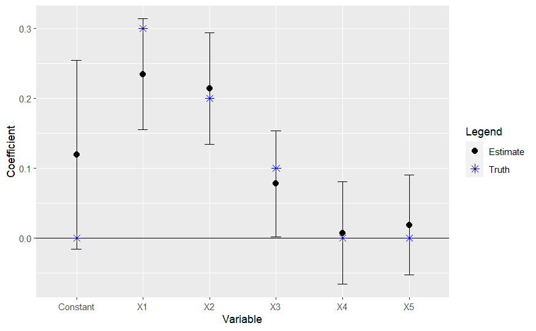

```r
se2 = lm_fit2$std.error
data.frame(Variable = c("Constant",paste0("X",1:5)),
           Coefficient = lm_fit2$coefficients,
           cil = lm_fit2$coefficients - 1.96*se2,
           ciu = lm_fit2$coefficients + 1.96*se2,
           truth = c(0,rho[1:5])) %>%
  ggplot(aes(x=Variable,y=Coefficient,ymin=cil,ymax=ciu)) + geom_point(size=2.5,aes(colour="Estimate",shape="Estimate")) + geom_errorbar(width=0.15)  +
  geom_hline(yintercept=0) + geom_point(aes(x=Variable,y=truth,colour="Truth",shape="Truth"),size=2.5) +
  scale_colour_manual(name="Legend", values = c("black","blue")) +
  scale_shape_manual(name="Legend",values = c(19,8))
```

The estimated coefficients are close to the true ones and the true coefficients are covered by the respective 95% confidence intervals.

Thus, it is also not surprising that the correlation of the resulting fitted values with the true CATE is obvious and strong:

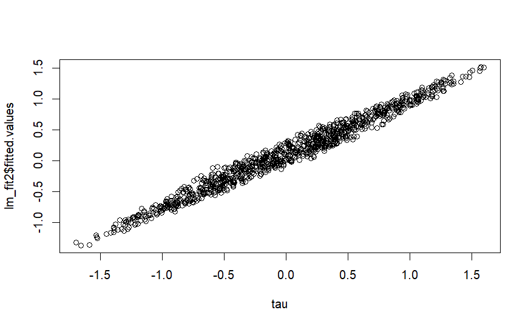

```r
plot(tau,lm_fit2$fitted.values)
```

### 5-fold cross-fitting with `causalDML` package

Next we consider 5-fold cross-fitting using the `causalDML` package. This requires to first estimate the standard average effects:

```r
# 5-fold cross-fitting with causalDML package
# Create learner
forest = create_method("forest_grf",args=list(tune.parameters = "all"))
# Run
aipw = DML_aipw(y,w,x,ml_w=list(forest),ml_y=list(forest),cf=5)
summary(aipw$APO)
```

```
          APO         SE
0 -0.03810188 0.05205454
1  0.06029791 0.06423154
```

```r
summary(aipw$ATE)
```

```
          ATE      SE      t      p
1 - 0 0.09840 0.07321 1.3441 0.1792
```

It stores the pseudo-outcome in the created object (`object$ATE$delta`) such that we can use it in the next step without rerunning the ML steps again:

```r
lm_fit5 = lm_robust(aipw$ATE$delta~x[,1:5])
summary(lm_fit5)
```

```
Call:
lm_robust(formula = aipw$ATE$delta ~ x[, 1:5])

Standard error type:  HC2

Coefficients:
            Estimate Std. Error t value  Pr(>|t|)  CI Lower CI Upper  DF
(Intercept) 0.100617    0.07027  1.4318 1.525e-01 -0.037284  0.23852 994
x[, 1:5]1   0.244793    0.04073  6.0102 2.599e-09  0.164867  0.32472 994
x[, 1:5]2   0.231625    0.04135  5.6014 2.751e-08  0.150479  0.31277 994
x[, 1:5]3   0.079803    0.03940  2.0256 4.308e-02  0.002491  0.15711 994
x[, 1:5]4   0.008015    0.03796  0.2112 8.328e-01 -0.066472  0.08250 994
x[, 1:5]5   0.023393    0.03736  0.6261 5.314e-01 -0.049922  0.09671 994

Multiple R-squared:  0.07435 ,  Adjusted R-squared:  0.0697
F-statistic: 14.41 on 5 and 994 DF,  p-value: 1.215e-13
```

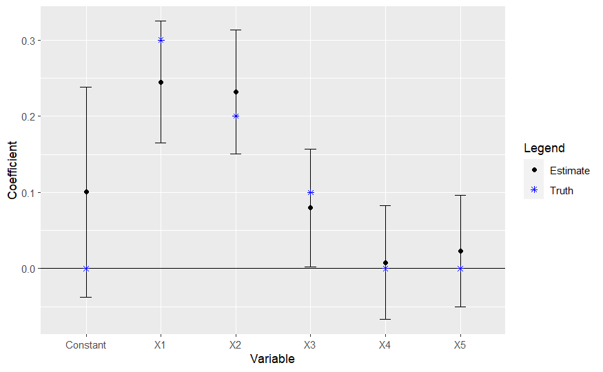

```r
se5 = lm_fit5$std.error
data.frame(Variable = c("Constant",paste0("X",1:5)),
           Coefficient = lm_fit5$coefficients,
           cil = lm_fit5$coefficients - 1.96*se5,
           ciu = lm_fit5$coefficients + 1.96*se5,
           truth = c(0,rho[1:5])) %>%
  ggplot(aes(x=Variable,y=Coefficient,ymin=cil,ymax=ciu)) + geom_point(linewidth=2.5,aes(colour="Estimate",shape="Estimate")) + geom_errorbar(width=0.15)  +
  geom_hline(yintercept=0) + geom_point(aes(x=Variable,y=truth,colour="Truth",shape="Truth"),linewidth=2.5) +
  scale_colour_manual(name="Legend", values = c("black","blue")) +
  scale_shape_manual(name="Legend",values = c(19,8))
```

Again the predicted CATEs and the true ones are highly correlated:

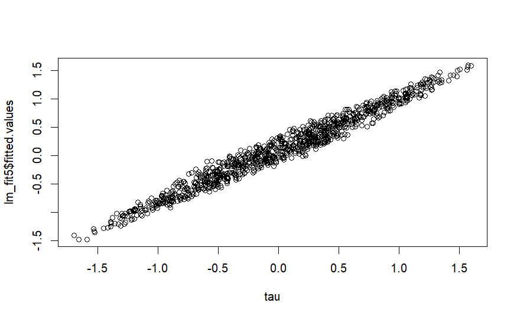

```r
plot(tau,lm_fit5$fitted.values)
```

*Remark:* This procedure would estimate the Best Linear Predictor of the CATE with respect to the five variables in the (likely) case that the underlying CATE function is not really linear.

# Non-parametric heterogeneity

Now we revisit the second DGP of notebook [SNB_AIPW_DML](https://mcknaus.github.io/assets/notebooks/SNB/SNB_AIPW_DML.nb.html) with zero ATE but highly nonlinear effect heterogeneity:

- $p=10$ independent covariates $X_1,...,X_k,...,X_{10}$ drawn from a uniform distribution: $X_k \sim uniform(-\pi,\pi)$
- The treatment model is $W \sim Bernoulli(\underbrace{\Phi(sin(X_1))}_{e(X)})$, where $\Phi(\cdot)$ is the standard normal cumulative density function
- The outcome model of the controls is $Y(0) = \underbrace{cos(X_1+1/2\pi)}_{m_0(X)}+ \varepsilon$, with $\varepsilon \sim N(0,1)$
- The outcome model of the treated is $Y(1) = \underbrace{sin(X_1)}_{m_1(X)}+ \varepsilon$, with $\varepsilon \sim N(0,1)$
- The treatment effect function is $\tau(X) = sin(X_1) - cos(X_1+1/2\pi)$

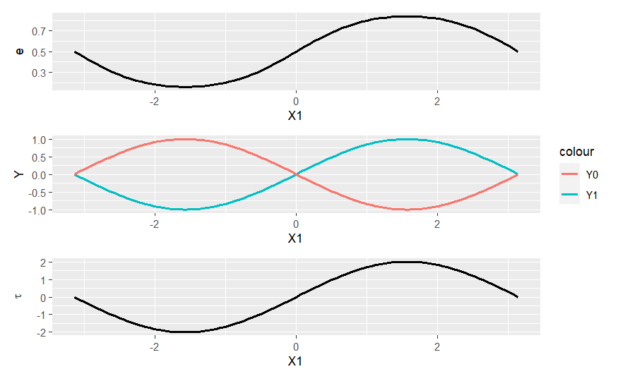

```r
x = matrix(runif(n*p,-pi,pi),ncol=p)
e = function(x){pnorm(sin(x))}
m1 = function(x){sin(x)}
m0 = function(x){cos(x+1/2*pi)}
tau = function(x){m1(x) - m0(x)}
w = rbinom(n,1,e(x[,1]))
y = w*m1(x[,1]) + (1-w)*m0(x[,1]) + rnorm(n,0,1)

g1 = data.frame(x = c(-pi, pi)) %>% ggplot(aes(x)) + stat_function(fun=e,linewidth=1) + ylab("e") + xlab("X1")
g2 = data.frame(x = c(-pi, pi)) %>% ggplot(aes(x)) + stat_function(fun=m1,linewidth=1,aes(colour="Y1")) +
  stat_function(fun=m0,linewidth=1,aes(colour="Y0")) + ylab("Y") + xlab("X1")
g3 = data.frame(x = c(-pi, pi)) %>% ggplot(aes(x)) + stat_function(fun=tau,linewidth=1) + ylab(expression(tau)) + xlab("X1")
g1 / g2 / g3
```

## GATE estimation with kernel regression

### Hand-coded 2-fold cross-fitting

Consider we are interested in the heterogeneity with respect to the first covariate $X_1$.

We draw a sample of $N=1000$ and estimate the nuisance parameters $e(X)=E[W|X]$, $m(0,X)=E[Y|W=0,X]$ and $m(1,X)=E[Y|W=1,X]$ using honest random forest with self-tuned tuning parameters and all ten covariates.

We first handcode 2-fold cross-validation and plug the resulting nuisance parameters into the pseudo outcome formula:

```r
m0hat = m1hat = ehat = rep(NA,n)
# Draw random indices for sample 1
index_s1 = sample(1:n,n/2)
# Create S1
x1 = x[index_s1,]
w1 = w[index_s1]
y1 = y[index_s1]
# Create sample 2 with those not in S1
x2 = x[-index_s1,]
w2 = w[-index_s1]
y2 = y[-index_s1]
# Model in S1, predict in S2
rf = regression_forest(x1,w1,tune.parameters = "all")
ehat[-index_s1] = predict(rf,newdata=x2)$predictions
rf = regression_forest(x1[w1==0,],y1[w1==0],tune.parameters = "all")
m0hat[-index_s1] = predict(rf,newdata=x2)$predictions
rf = regression_forest(x1[w1==1,],y1[w1==1],tune.parameters = "all")
m1hat[-index_s1] = predict(rf,newdata=x2)$predictions
# Model in S2, predict in S1
rf = regression_forest(x2,w2,tune.parameters = "all")
ehat[index_s1] = predict(rf,newdata=x1)$predictions
rf = regression_forest(x2[w2==0,],y2[w2==0],tune.parameters = "all")
m0hat[index_s1] = predict(rf,newdata=x1)$predictions
rf = regression_forest(x2[w2==1,],y2[w2==1],tune.parameters = "all")
m1hat[index_s1] = predict(rf,newdata=x1)$predictions
# generate pseudo-outcome
pseudo_y =  m1hat - m0hat +
  w*(y-m1hat) / ehat - (1-w)*(y-m0hat) / (1-ehat)
```

Now we use the pseudo-outcome in a kernel regression with the only covariate being $X_1$. We cross-validate the bandwidth of the kernel regression, run the estimation with the `np` package and plot the estimated curve:

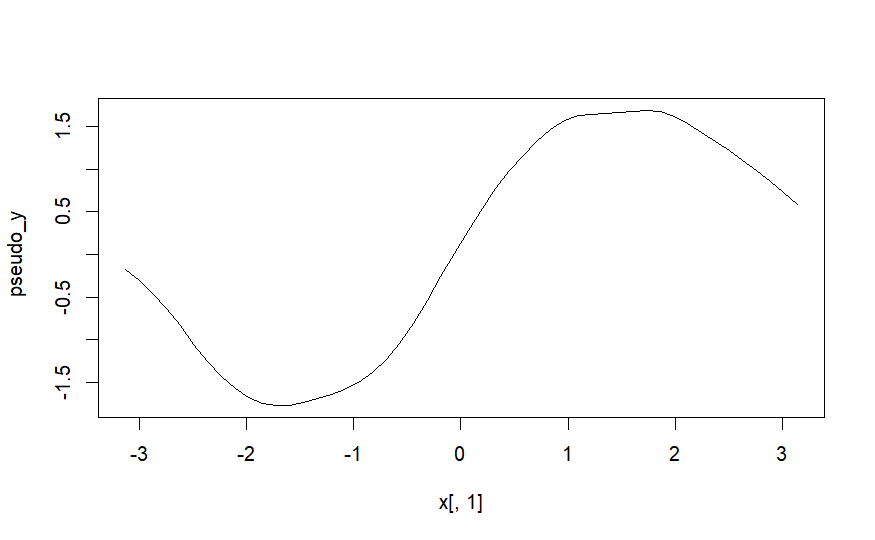

```r
z = as.data.frame(x[,1])
# Crossvalidate bandwidth
bwobj = npregbw(ydat = pseudo_y, xdat = z, ckertype = 'gaussian', ckerorder = 2, regtype = 'lc', bwmethod = 'cv.ls')
bws = bwobj$bw
# Undersmoothing, i.e. chose a slightly smaller bandwidth than was cross-validated
bw = bwobj$bw * 0.9
cate_model = npreg(tydat = pseudo_y, txdat = z, bws=bw, ckertype = 'gaussian', ckerorder = 2, regtype = 'lc')

plot(cate_model)
```

This looks very similar to the true function.

### 5-fold cross-fitting with `causalDML` package

Next we consider 5-fold cross-fitting using the `causalDML` package. This requires to first estimate the standard average effects:

```r
# 5-fold cross-fitting with causalDML package
# Create learner
forest = create_method("forest_grf",args=list(tune.parameters = "all"))
# Run
aipw = DML_aipw(y,w,x,ml_w=list(forest),ml_y=list(forest),cf=5)
summary(aipw$APO)
```

```
          APO         SE
0 -0.01052922 0.05749346
1  0.08131356 0.05128989
```

```r
summary(aipw$ATE)
```

```
           ATE       SE     t      p
1 - 0 0.091843 0.082444 1.114 0.2655
```

It stores the pseudo-outcome in the created object (`object$ATE$delta`) such that we can use it in the next step without rerunning the ML steps again. The full procedure is implemented in the `kr_cate` function:

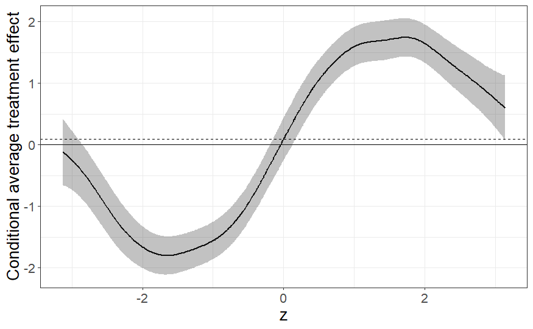

```r
kernel_reg_x1 = kr_cate(aipw$ATE$delta,x[, 1])
plot(kernel_reg_x1)
```

Finally, lets check whether we find something that is not there by checking heterogeneity with respect to $X_2$.

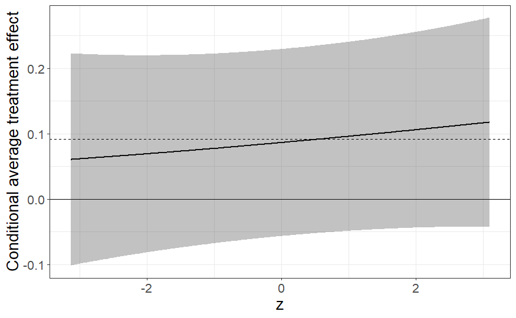

```r
kernel_reg_x2 = kr_cate(aipw$ATE$delta,x[, 2])
plot(kernel_reg_x2)
```

We find no evidence of heterogeneous effects along $X_2$, as we should.

## GATE estimation with series regression

### Hand-coded 2-fold cross-fitting

Consider again that we are interested in the heterogeneity with respect to the first covariate $X_1$. We reuse first the handcoded 2-fold cross-fitted pseudo outcome in a series regression with B-splines using the `crs` package

```r
spline_gate = crs(pseudo_y ~ as.matrix(z))
```

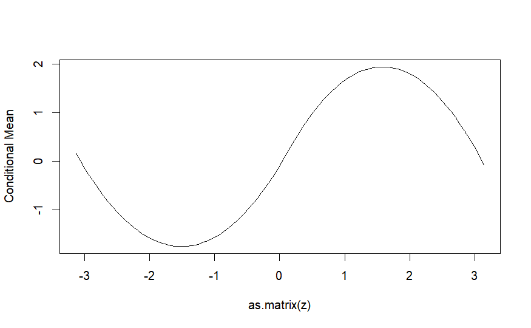

```r
plot(spline_gate,mean=T)
```

Also the spline function nicely approximates the true function.

### 5-fold cross-fitting with *causalDML* package

Again, we can reuse the pseudo-outcome (`object\$ATE\$delta`) and use the `spline_cate` function of the `causalDML` package:

```r
spline_reg_x1 = spline_cate(aipw$ATE$delta,x[, 1])
```

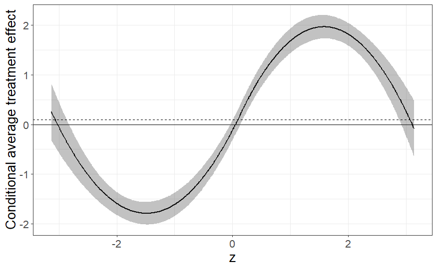

```r
plot(spline_reg_x1)
```

Again this looks like the true function. Most importantly, the x-axis is included in the 95% confidence intervals where it should be $\Rightarrow$ We find what we should find.

Finally, lets check whether we find something that is not there by checking heterogeneity with respect to $X_2$.

```r
spline_reg_x2 = spline_cate(aipw$ATE$delta,x[, 2])
```

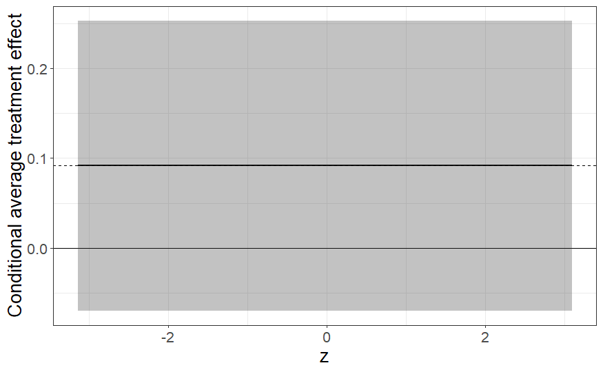

```r
plot(spline_reg_x2)
```

We find no evidence of heterogeneous effects along $X_2$, as we should.

## Take-away

- Estimating heterogeneous effects with pre-specified heterogeneity variables is just a few lines of additional code reusing the pseudo-outcome from the average effect estimation
- We can model effect sizes as we are used to modeling outcome levels by using the right pseudo-outcome

## Suggestions to play with the toy model

Some suggestions:

- Increase/decrease the number of observations
- Create a non-linear CATE in the first part
- Change the treatment shares